# FORDGOBIKE TripData

## by Abdallah Saoud

## Intro

**A marketing CEO at a bike company is looking to lanch a new service ...but did not know when to launch , where to lanch and what adjustments could be made to fit the largest group of your customers.**

In order to know when to launch we will need to see which day is the **busiest day**

and where to launch we will need to know the **busiest station**

as for the largest group we will be looking at **age , gender & user type**

```python
df.info()
```

```
<class 'pandas.core.frame.DataFrame'>
RangeIndex: 183412 entries, 0 to 183411
Data columns (total 16 columns):
 #   Column                   Non-Null Count   Dtype
---  ------                   --------------   -----
 0   duration_sec             183412 non-null  int64
 1   start_time               183412 non-null  object
 2   end_time                 183412 non-null  object
 3   start_station_id         183215 non-null  float64
 4   start_station_name       183215 non-null  object
 5   start_station_latitude   183412 non-null  float64
 6   start_station_longitude  183412 non-null  float64
 7   end_station_id           183215 non-null  float64
 8   end_station_name         183215 non-null  object
 9   end_station_latitude     183412 non-null  float64
 10  end_station_longitude    183412 non-null  float64
 11  bike_id                  183412 non-null  int64
 12  user_type                183412 non-null  object
 13  member_birth_year        175147 non-null  float64
 14  member_gender            175147 non-null  object
 15  bike_share_for_all_trip  183412 non-null  object
dtypes: float64(7), int64(2), object(7)
memory usage: 22.4+ MB
```

### USER TYPE 'Customer Vs Subscriber'

#### how many customers vs subscribers and how many are males and females ?

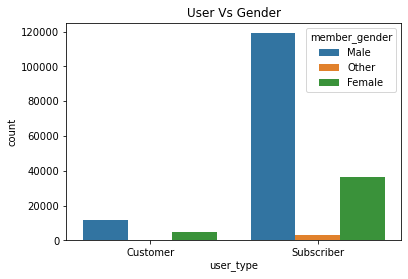

```python
#checking the amount of users and thier types and gender
sb.countplot(data = df , x = 'user_type', hue = 'member_gender' )
plt.title('User Vs Gender');
```

**as we can see the major segment we have are male subscribers of about 120K**

### Memeber Gender count " who wins"

##### how many gender types we have ?

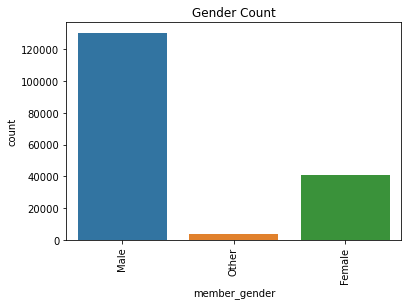

```python
#checking how many of each gender we have in our data set
sb.countplot(data = df , x = 'member_gender' )
plt.xticks(rotation=90)
plt.title('Gender Count');
```

**Majority are male users of more than 120K.**

###### What is the Most common ages are 28 and 33 so the segment is going to be youth ?

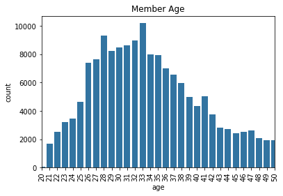

```python
#finding the relation between age and trip duration
sb.countplot(data = df , x = 'age', color = sb.color_palette()[0] , label = 'Member Age' )
fig = plt.gcf()
fig.set_size_inches( 6, 4)
plt.xticks(rotation = 90)
plt.title('Member Age')
plt.xlim(0,30);
```

As we can see top ages are between 28 and 33

```python
#Naming_weekdays
df['weekday'] = pd.to_datetime(df['start_date']).dt.day_name()
```

### checking the busiest day

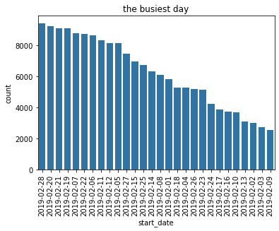

```python
sb.countplot(data = df , x = 'start_date' ,
             color = sb.color_palette()[0] ,
             order = df.start_date.value_counts().index )
#orderd the data to get the busiest day
plt.xticks(rotation=90)
plt.title('the busiest day');
```

As we can see 28/02/2019 which is thursday is the busiest day

### checking the busiest Station

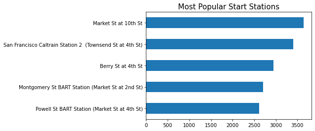

```python
#finding the top 5 stations
plt.title('Most Popular Start Stations', fontsize=15)
df.start_station_name.value_counts(ascending=True).tail(5).plot.barh();
```

> -Bivarriate plots

**As We can see from the previous exploration attempts that there are some elments that coud affect our judgments so further more we're going to be exploring together the trip duration value just to see if there is a segment that uses our services more than the other**

#### Does gender affect trip duration ?

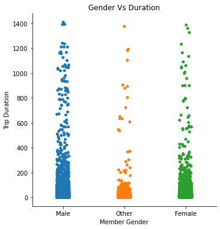

```python
sb.catplot(x="member_gender", y="duration_min", data = df)
plt.xlabel('Member Gender')
plt.ylabel('Trip Duration')
plt.title('Gender Vs Duration');
```

**Male users show more usage as you can see the first coulmn is more dense from the bottom up than the others.**

**And also we wanted to check if age elment affects trip duartion , so as you can see the density from 30 to 40, of course there are more users at thier 30s ride for long duration but as you can see amazingly there are some users at thier 60s for one of the longest durations**

[figure not shown]

```python
#classfing catagorical vakues and comparing age to duration to see if one gender dominates the longest duration
sb.scatterplot(x="age", y="duration_min", data = df , hue = 'member_gender' )
plt.xlabel('Trip Duration')
plt.ylabel('age')
plt.xlim(20,95)
plt.title ('Age VS Duration');
```

**Checking the busiest day of the week and by which gender**

[figure not shown]

```python
#checking week day with gender
gender_classes = ['Male', 'Female', 'Other']

# Returns the types for member_gender with the categories and orderednessb
gclasses = pd.api.types.CategoricalDtype(ordered=True, categories=gender_classes)
df['gender_type'] = df['member_gender'].apply(lambda x:x.split()[0])
day_order = df['weekday'].value_counts().index
plt.figure(figsize = [10,10])
sb.countplot(data = df, x = 'weekday', hue = 'gender_type',order=day_order);
plt.title('Week day Vs User type',fontsize = 15);
```

> the busiest day of teh ewwk is thursday and mostly by male users

##### is there a certian day with more males than females and how long does they ride for ?

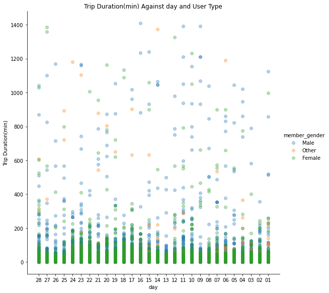

```python
g = sb.FacetGrid(data =  df, hue = 'member_gender', height = 8)
g.map(plt.scatter, 's_day','duration_min', alpha = 1/3)
g.add_legend()
plt.title('Trip Duration(min) Against day and User Type')
plt.xlabel('day')
plt.ylabel('Trip Duration(min)');
```

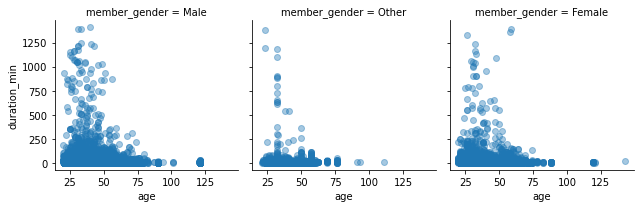

```python
#checking user type with age and trip duration
g = sb.FacetGrid(data = df, col = 'member_gender')
g.map(plt.scatter, 'age','duration_min',alpha = 2/5);
```

> - Majorty of users are male. Majorty of male user range from 25 to 50 years old .
> - Majorty of female user range from 25 to 45 years old .

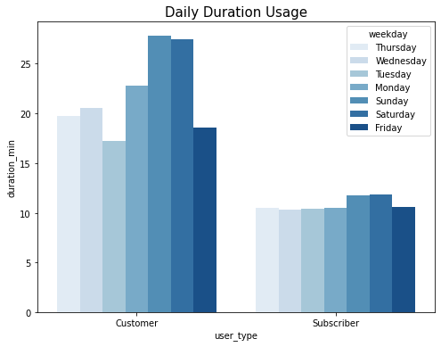

```python
#checking user type with weekday and trip duration
plt.figure(figsize=(8,6))
plt.title('Daily Duration Usage', fontsize=15)
sb.barplot(data=df, x='user_type', y='duration_min', ci=None,hue='weekday',palette = 'Blues');
```

> - Trip duration for Subscriber is almost the same regarding week day.
> - Trip duration for customer is higher than subscriber especially in Saturday and Sunday.